# Data Visualization

Jordache Ramjith

August 1, 2018

## Graph 1

```r
library(readxl)
data1 <- read_excel("C:/Users/Jordache/Google Drive/Radboud University/Copy of Data for graphs.xlsx",
    sheet = "graph1")
View(data1)
```

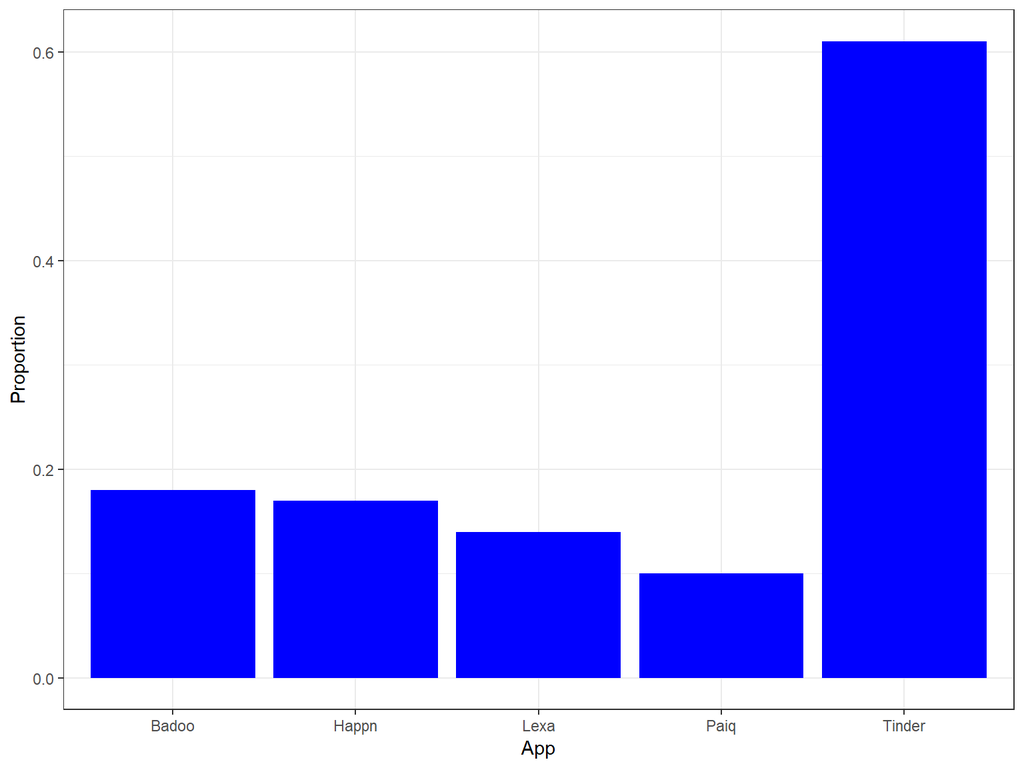

```r
library(ggplot2)
graph1 = ggplot(data = data1, aes(x = App, y = Proportion)) + geom_bar(stat = "identity",
    fill = "blue")
graph1
```

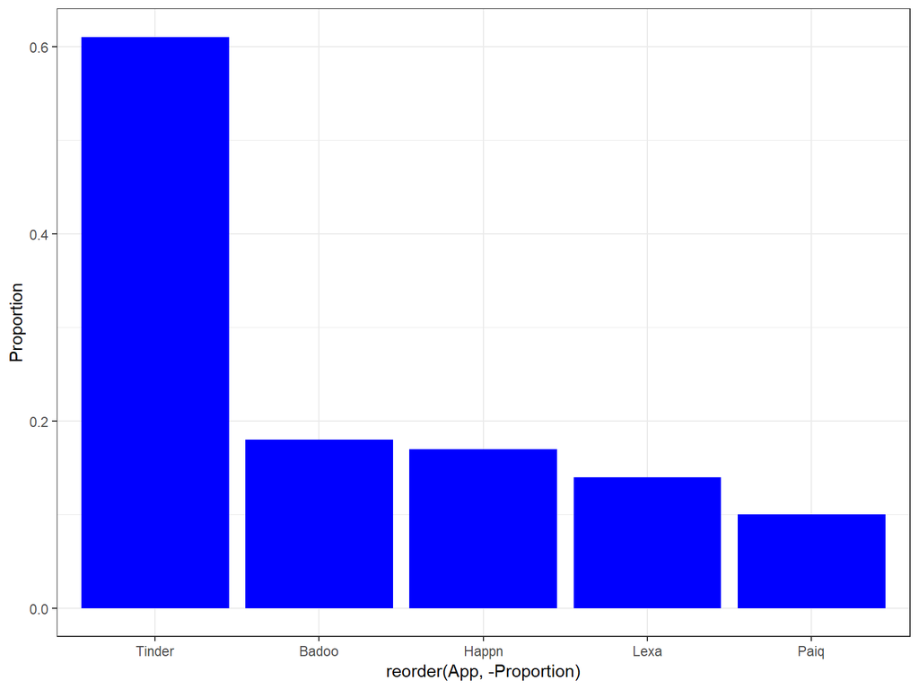

```r
# reorder category
graph1 = ggplot(data = data1, aes(x = reorder(App, -Proportion), y = Proportion)) +
    geom_bar(stat = "identity", fill = "blue")
graph1
```

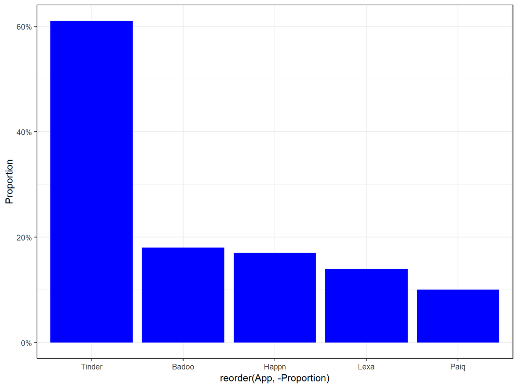

```r
# percentage scale
graph1 = graph1 + scale_y_continuous(labels = scales::percent)
graph1
```

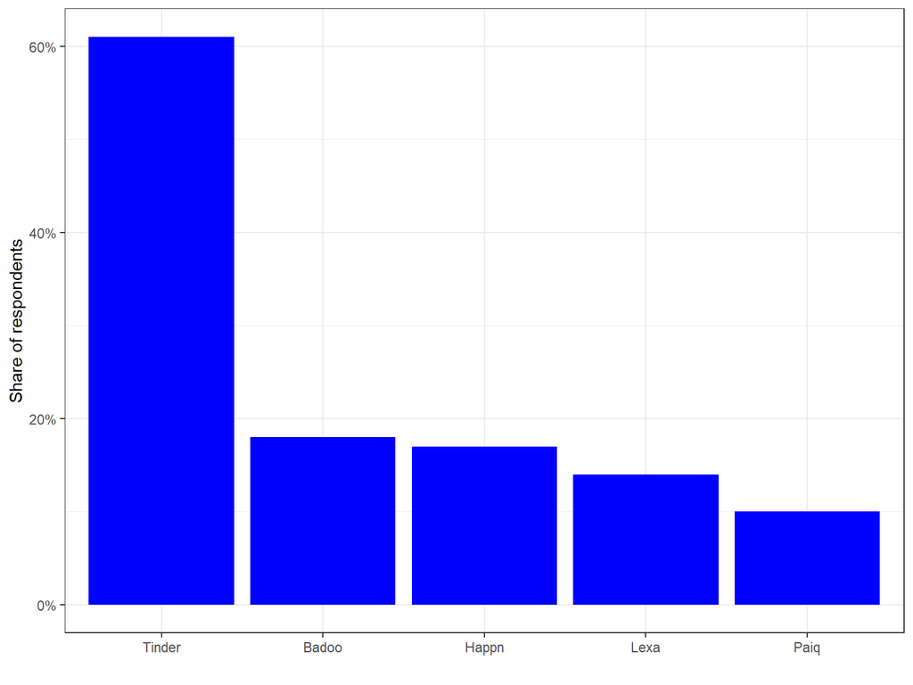

```r
# relabel the axis
graph1 = graph1 + xlab("") + ylab("Share of respondents")
graph1
```

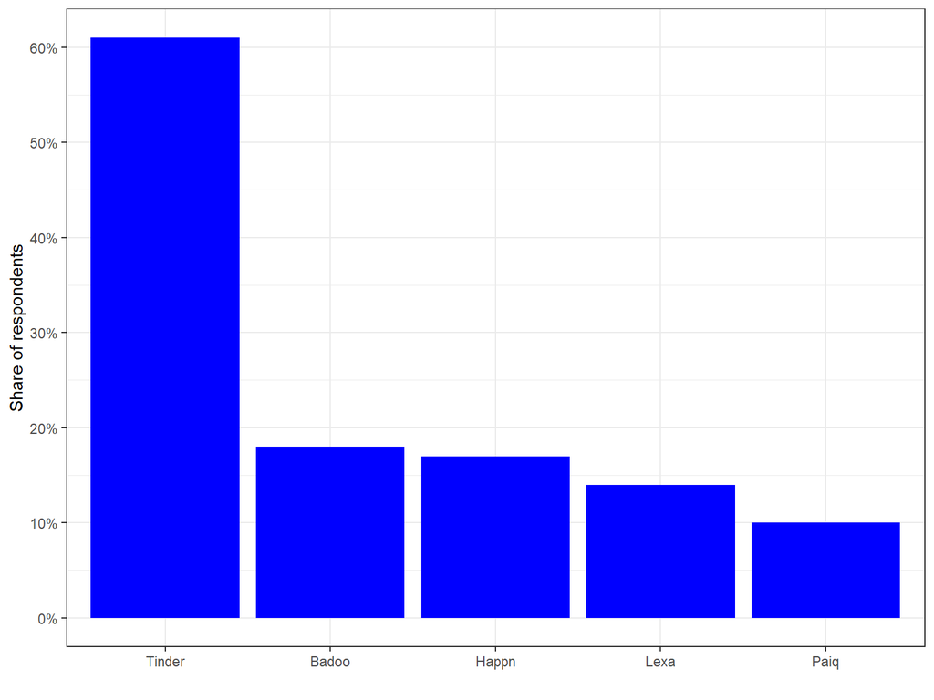

```r
# y axis 0 to 70
graph1 = graph1 + scale_y_continuous(breaks = seq(0, 0.7, 0.1), labels = scales::percent)
graph1
```

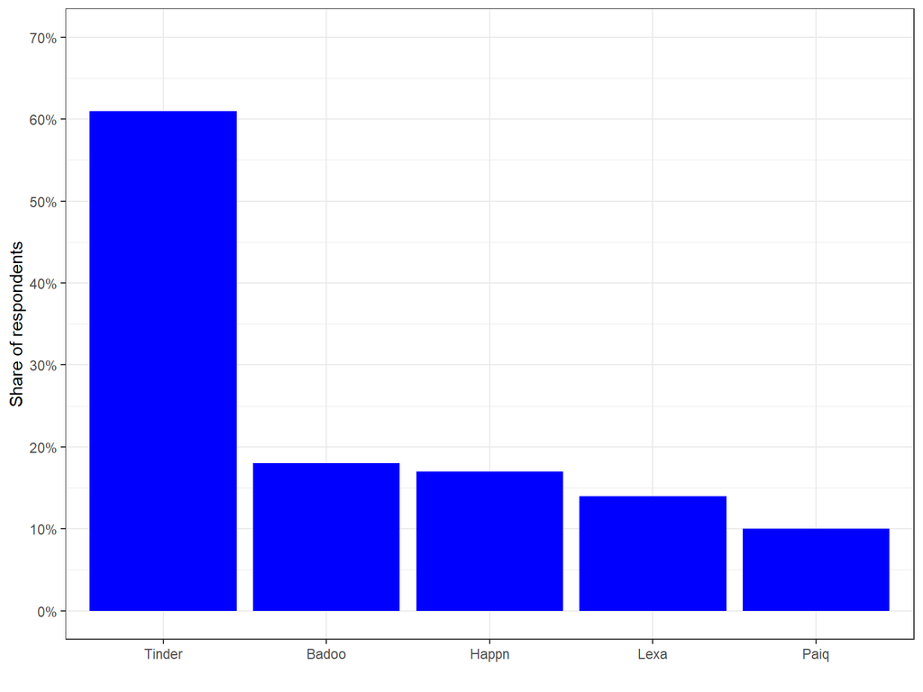

```r
# force y-axis to go up to 70%
graph1 = graph1 + scale_y_continuous(limits = c(0, 0.7), breaks = seq(0, 0.7, 0.1),
    labels = scales::percent)
graph1
```

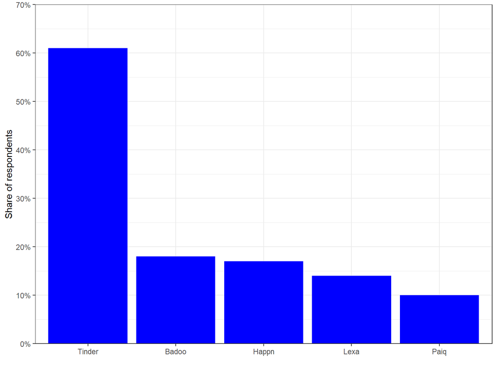

```r
# remove indents
graph1 = graph1 + scale_y_continuous(limits = c(0, 0.7), breaks = seq(0, 0.7, 0.1),
    labels = scales::percent, expand = c(0, 0))
graph1
```

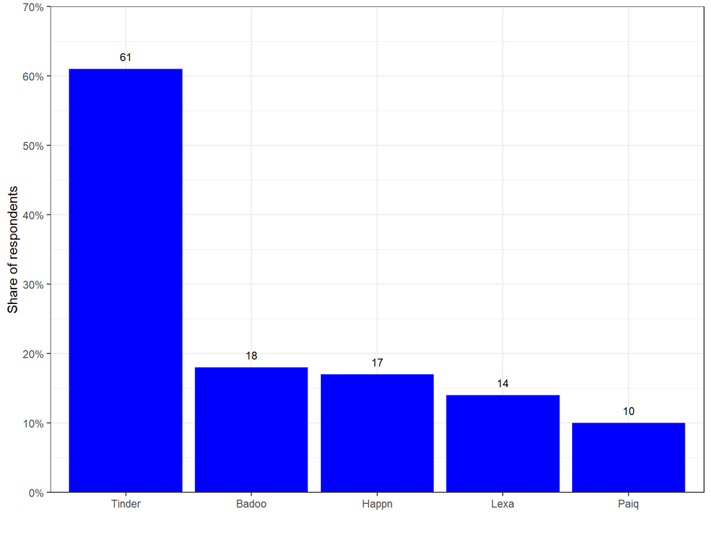

```r
# add numbers to the graph
graph1 = graph1 + geom_text(aes(label = Proportion * 100), size = 3, vjust = -1)
graph1
```

## GRAPH 2

```r
library(readxl)
data2 <- read_excel("C:/Users/Jordache/Google Drive/Radboud University/Copy of Data for graphs.xlsx",
    sheet = "Sheet2")
View(data2)
```

## Simple plot

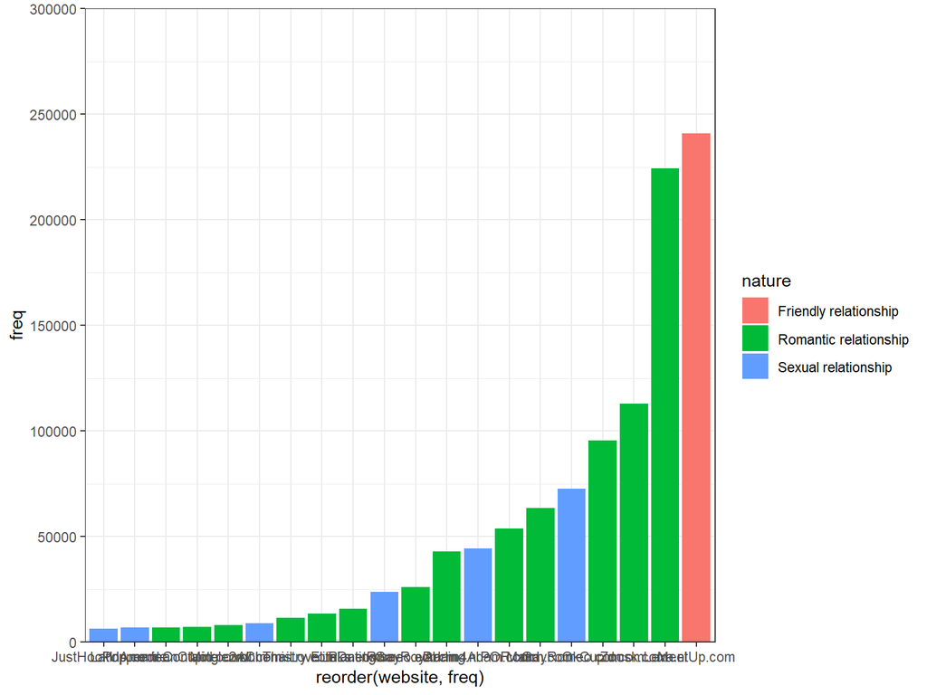

```r
graph2 = ggplot(data = data2, aes(x = reorder(website, freq), y = freq, fill = nature)) +
    scale_y_continuous(limits = c(0, 3e+05), breaks = seq(0, 3e+05, 50000), expand = c(0,
        0)) + geom_bar(stat = "identity")
graph2
```

## Flip the axis and remove axis labels

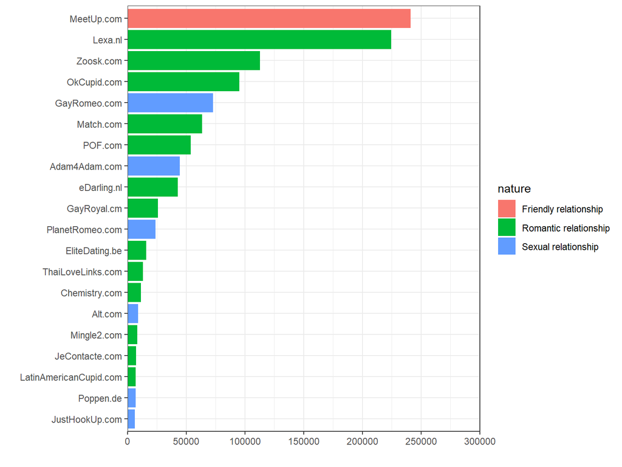

```r
graph2 = graph2 + coord_flip() + ylab("") + xlab("")
graph2
```

## Reposition and relabel the legend

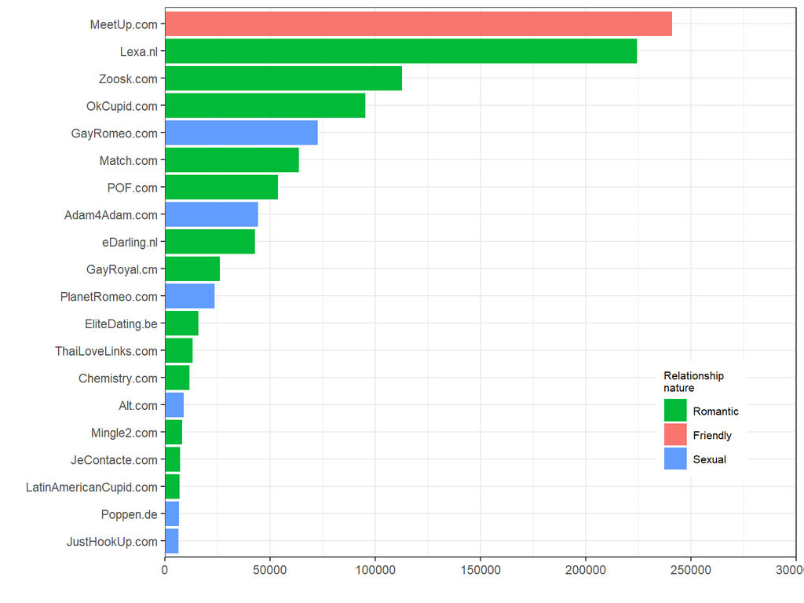

```r
# Note the difference between scale_fill_discrete and scale_color_discrete
graph2 = graph2 + scale_fill_discrete(name = "Relationship\nnature", breaks = c("Romantic relationship",
    "Friendly relationship", "Sexual relationship"), labels = c("Romantic", "Friendly",
    "Sexual")) + theme(legend.position = c(0.85, 0.25), legend.title = element_text(size = 8),
    legend.text = element_text(size = 8))
graph2
```

## Adjust scale limits on x axis and add numbers to the plot

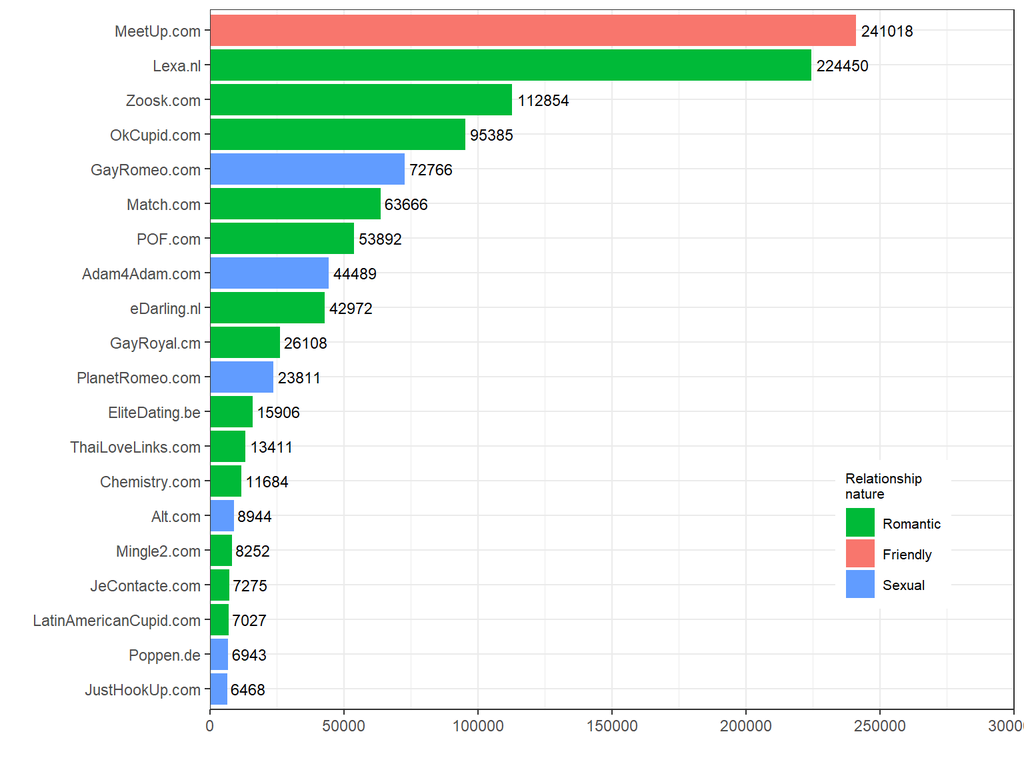

```r
# Adjusting the scale limits must be done before flipping the coordinates.
graph2 = graph2 + geom_text(aes(label = freq), size = 3, hjust = -0.1)
graph2
```

## Adding a title to the plot

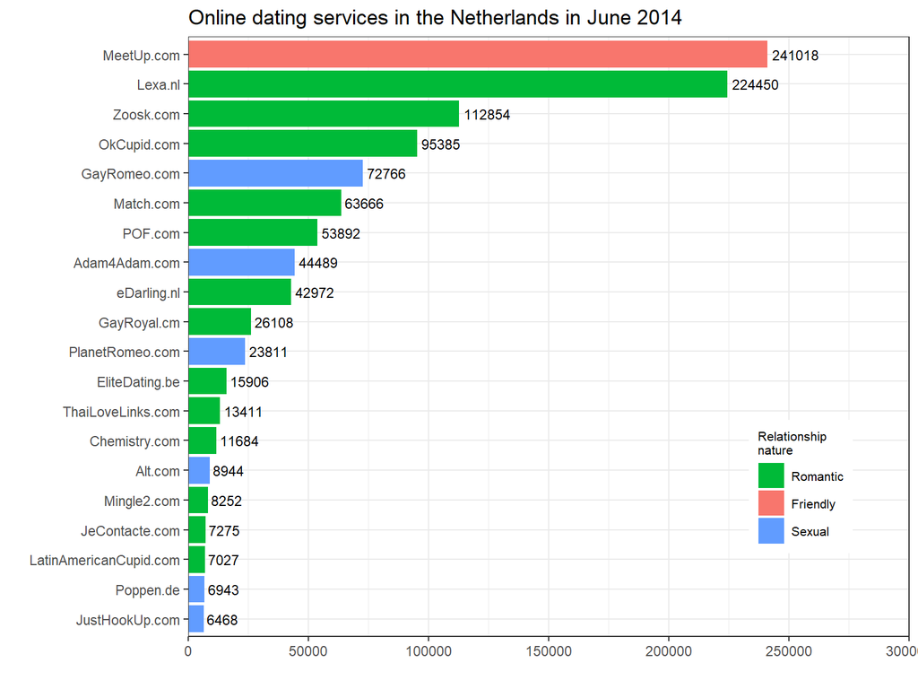

```r
graph2 = graph2 + ggtitle("Online dating services in the Netherlands in June 2014")
graph2
```

## Aesthetics

Remove the grey background.

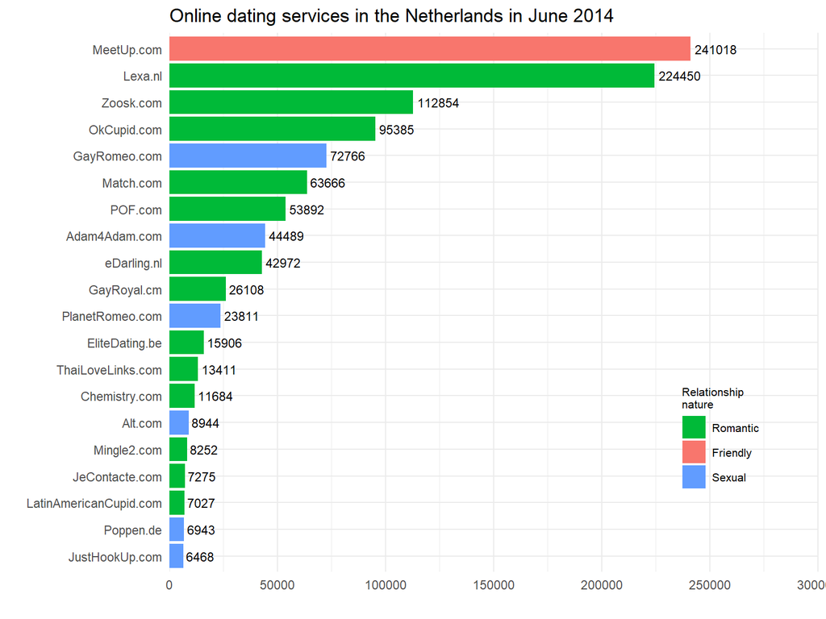

```r
# This must be done immediately after the ggplot function.
+theme_minimal()
```

## Remove grey AND the grids

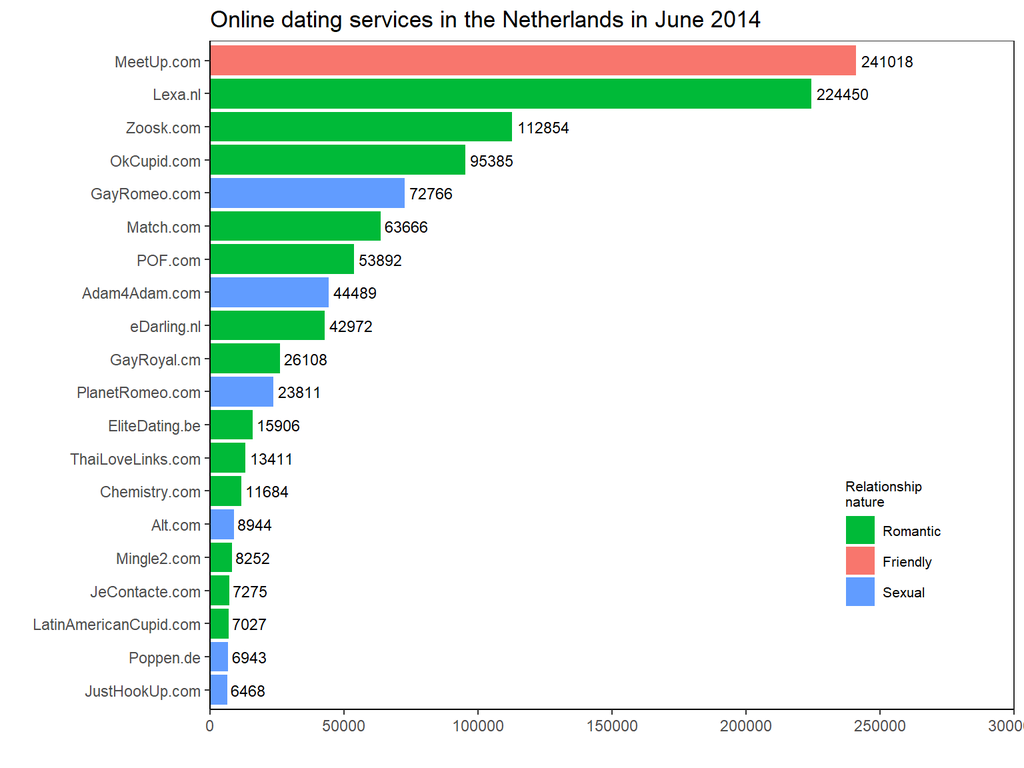

```r
+theme_bw() + theme(panel.grid.major = element_blank(), panel.grid.minor = element_blank(),
    panel.background = element_blank(), axis.line = element_line(colour = "black"))
```

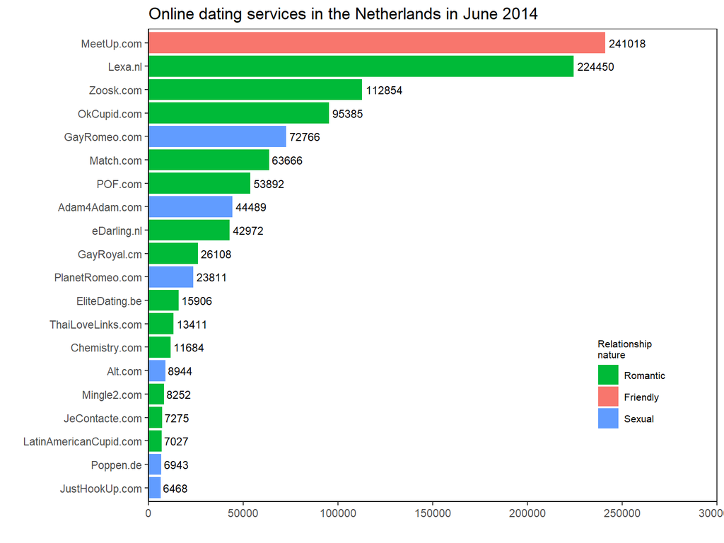

```r
# Must be added to the geom_bar statement.
+geom_bar(stat = "identity", position = position_dodge(width = 0.5))
```

## Changing colours

Darker version of the standard red/green/blue

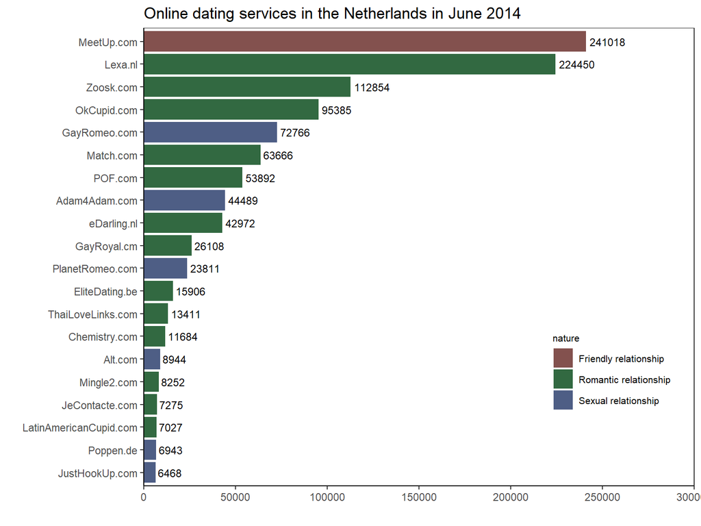

```r
graph2 + scale_fill_hue(l = 40, c = 35)
```

## Using RColorBrewer palettes

You can google to find the different palettes and codes. Example:

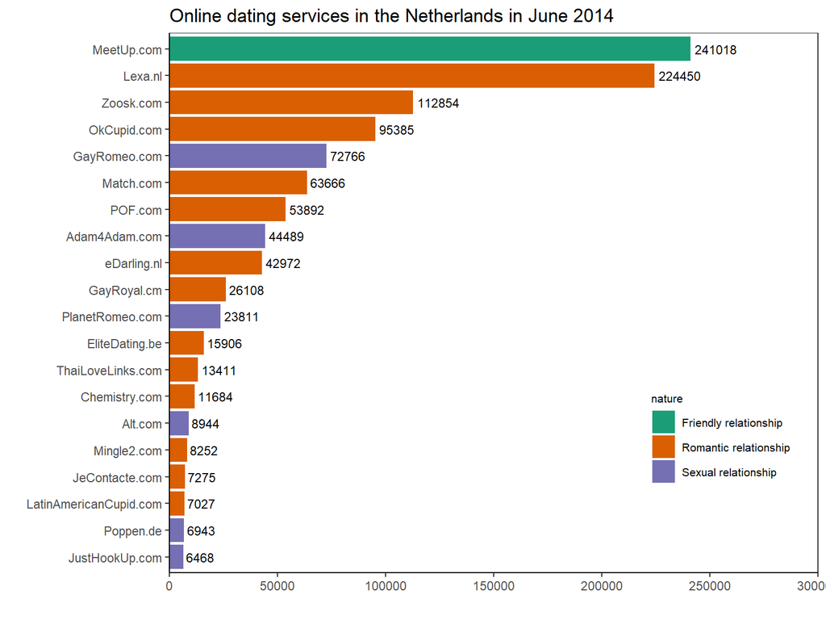

```r
graph2 + scale_fill_brewer(palette = "Dark2")
```

## Manual colours

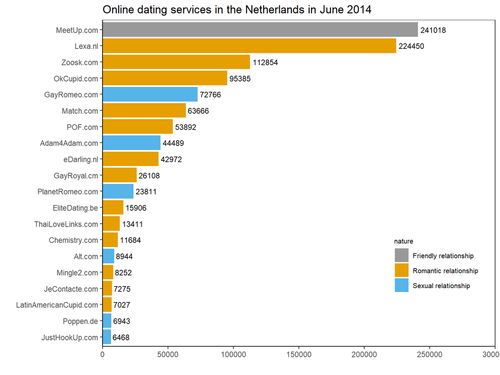

```r
graph2 + scale_fill_manual(values = c("#999999", "#E69F00", "#56B4E9"))
```

## Manual colours

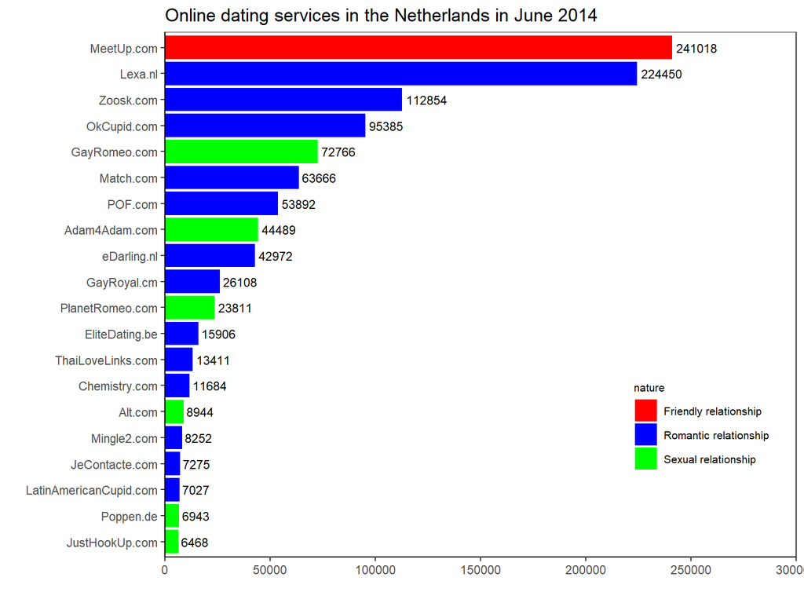

```r
graph2 + scale_fill_manual(values = c("red", "blue", "green"))
```

## Predefined colour names

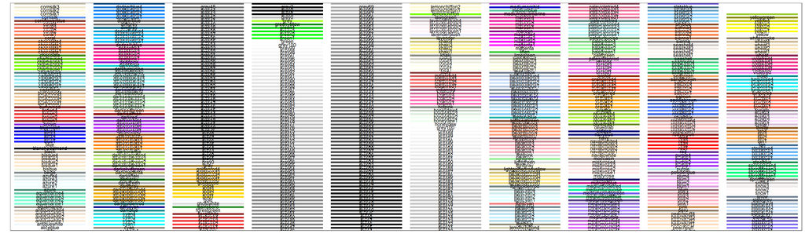

## Graph 3

```r
library(readxl)
data3 <- read_excel("C:/Users/Jordache/Google Drive/Radboud University/Copy of Data for graphs.xlsx",
    sheet = "Sheet4")
View(data3)
```

## Basic plot

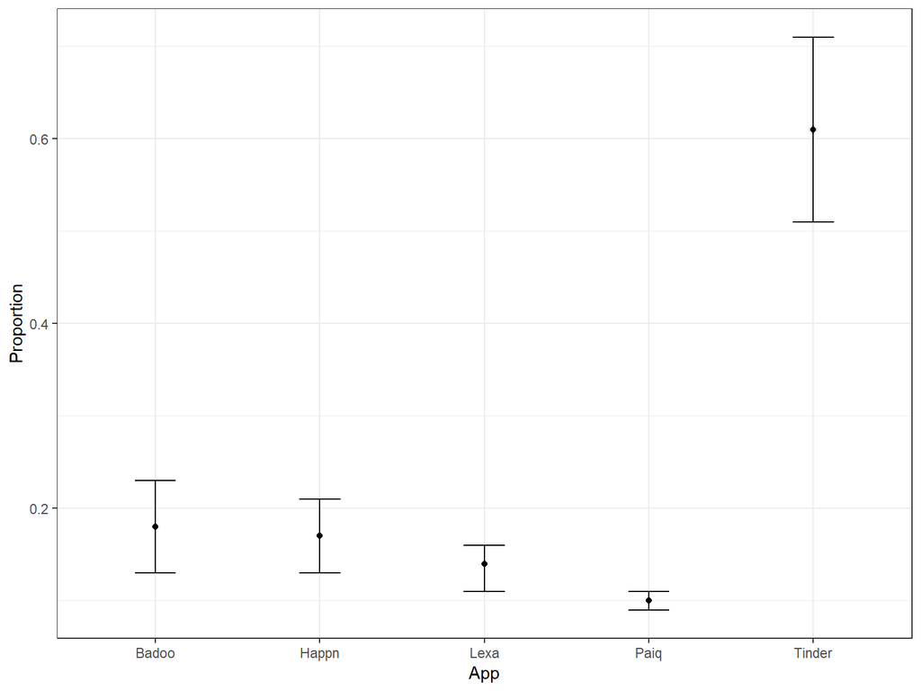

```r
graph3 = ggplot(data = data3, aes(x = App, y = Proportion, ymin = LCI, ymax = UCI)) +
    geom_point() + geom_errorbar(width = 0.25)
graph3
```

## Previous asthetics

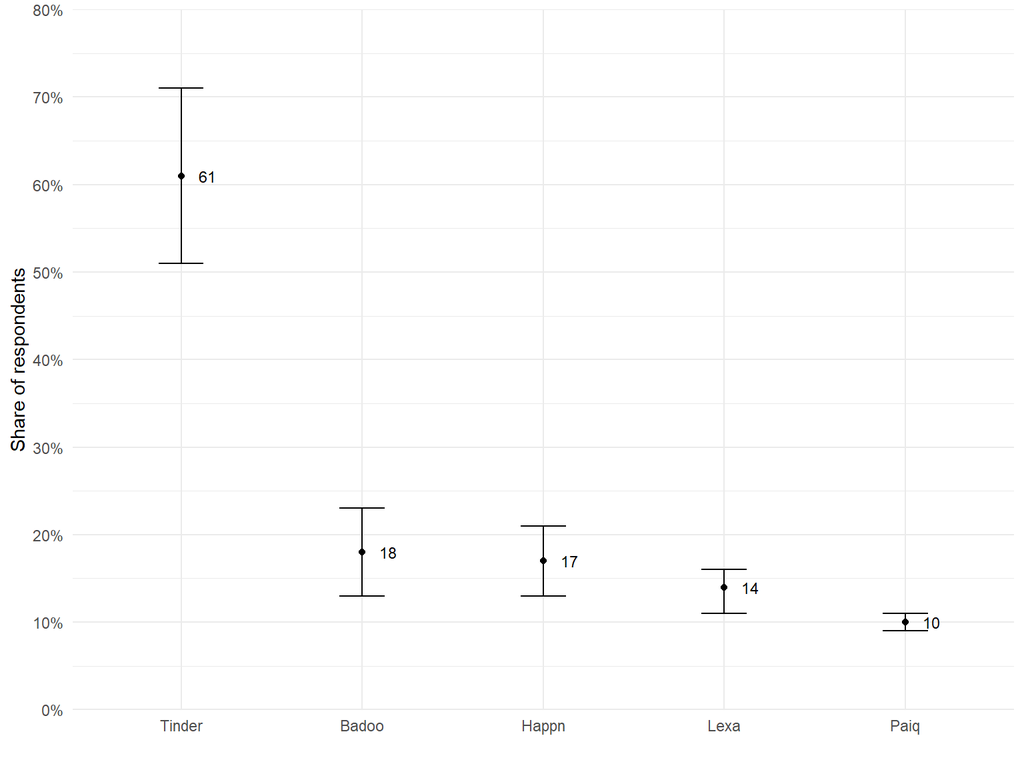

```r
graph3 = ggplot(data = data3, aes(x = reorder(App, -Proportion), y = Proportion,
    ymin = LCI, ymax = UCI)) + theme_minimal() + geom_point() + geom_errorbar(width = 0.25) +
    scale_y_continuous(limits = c(0, 0.8), breaks = seq(0, 0.8, 0.1), labels = scales::percent,
        expand = c(0, 0)) + xlab("") + ylab("Share of respondents") + geom_text(aes(label = Proportion *
    100), size = 3, hjust = -1)

graph3
```

## Graph 4

```r
library(readxl)
data4 <- read_excel("C:/Users/Jordache/Google Drive/Radboud University/Copy of Data for graphs.xlsx",
    sheet = "Sheet3")
View(data4)
```

## Simple plot

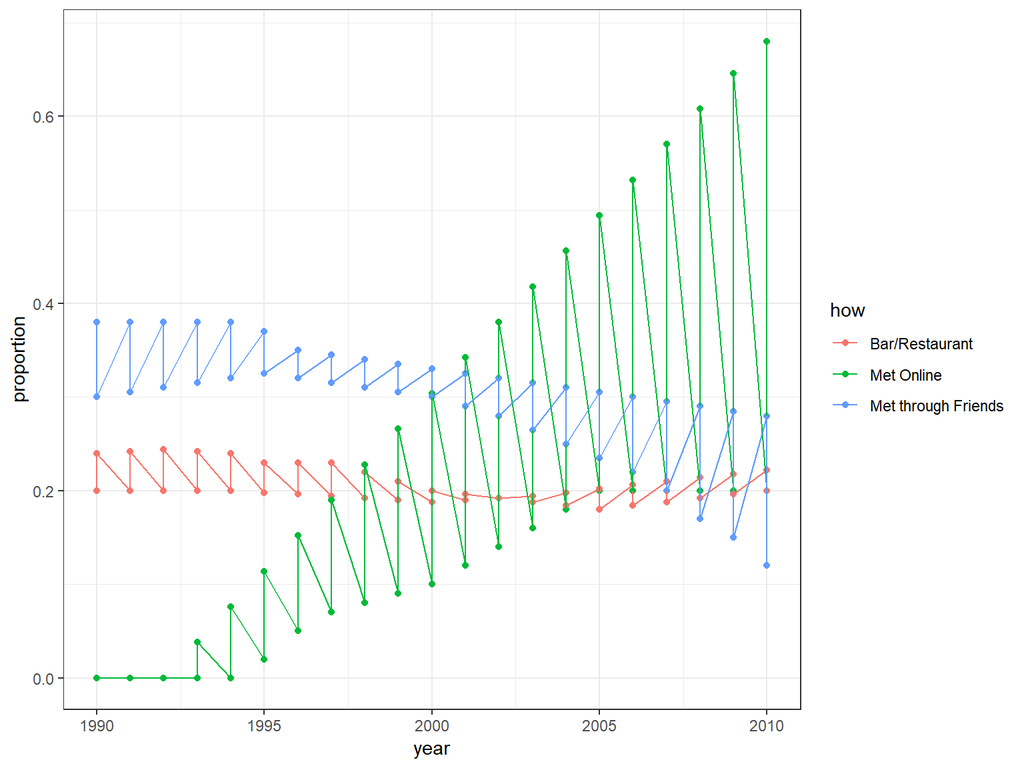

```r
graph4 = ggplot(data = data4, aes(x = year, y = proportion, color = how)) + geom_point() +
    geom_line()
graph4
```

## Heterosexual couples only

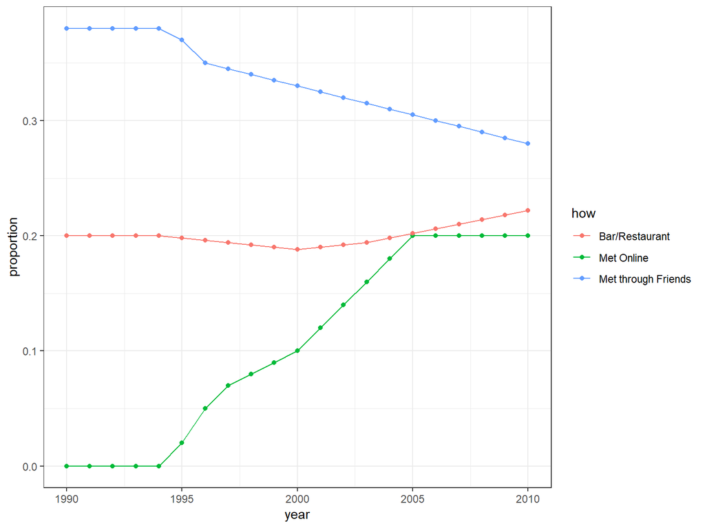

```r
graph4a = ggplot(data = data4[data4$orientation == "Heterosexual Couples", ], aes(x = year,
    y = proportion, color = how)) + geom_point() + geom_line()
graph4a
```

## Homosexual couples only

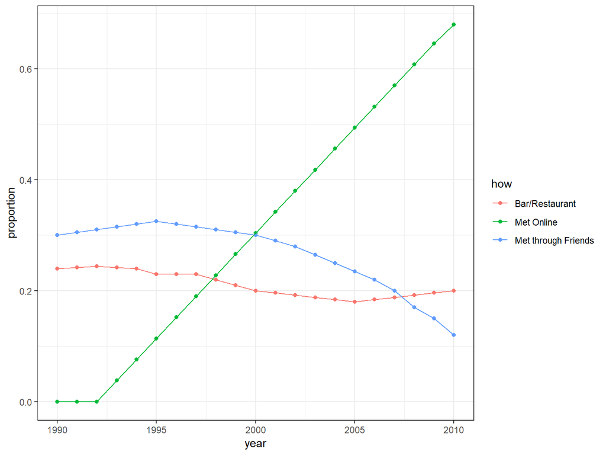

```r
graph4b = ggplot(data = data4[data4$orientation == "Homosexual Couples", ], aes(x = year,
    y = proportion, color = how)) + geom_point() + geom_line()
graph4b
```

## Together

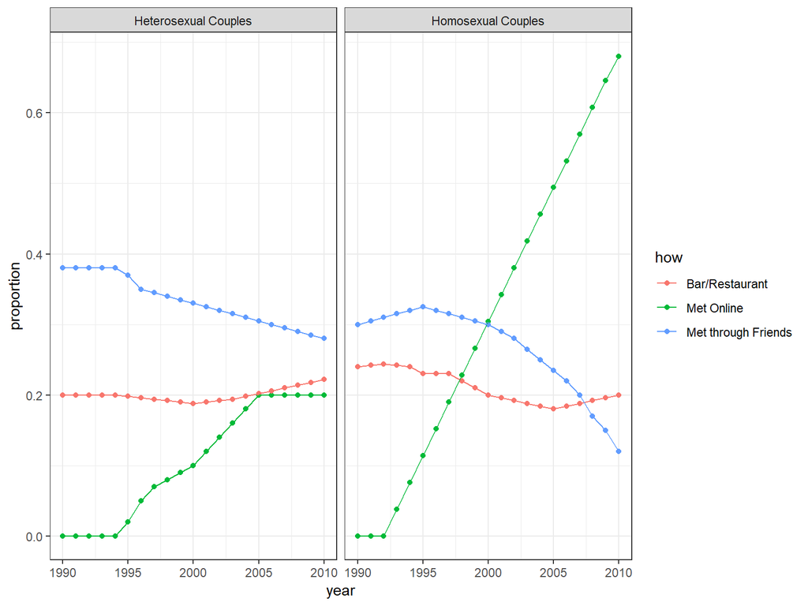

```r
graph4 = graph4 + facet_wrap(~orientation)
graph4
```

## Cleaned up plot

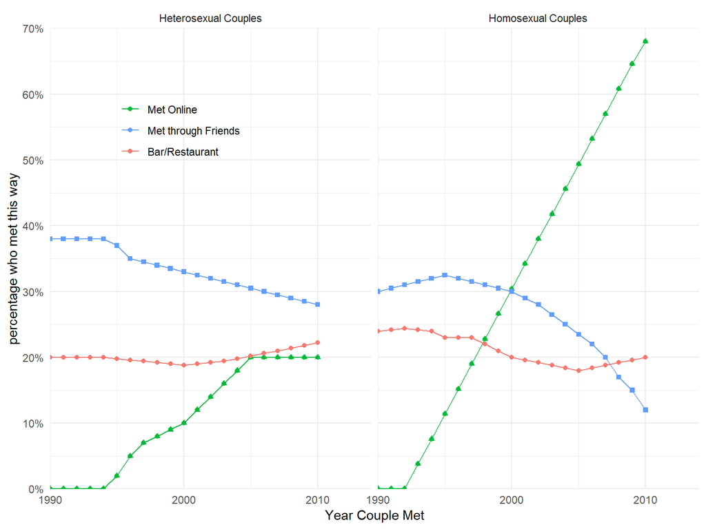

```r
graph4 = graph4 + theme_minimal() + xlab("Year Couple Met") + ylab("percentage who met this way") +
    scale_y_continuous(limits = c(0, 0.7), breaks = seq(0, 0.7, 0.1), labels = scales::percent,
        expand = c(0, 0)) + scale_x_continuous(limits = c(1990, 2014), breaks = seq(1990,
    2014, 10), expand = c(0, 0)) + theme(legend.position = c(0.2, 0.8)) + geom_point(aes(shape = how)) +
    scale_shape(guide = FALSE) + scale_color_discrete(name = "", breaks = c("Met Online",
    "Met through Friends", "Bar/Restaurant"))

graph4
```

## Assignment 1

1. Replicate the following graph. The data can be found in CLI_data_long.sav

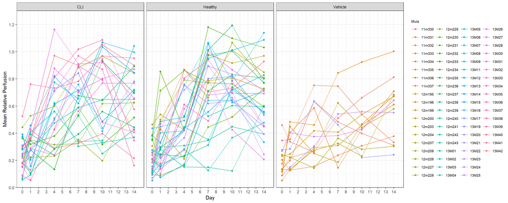

```r
library(haven)
CLI_data_long <- read_sav("Datasets/CLI_data_long.sav")
View(CLI_data_long)
```

2. In order to get the plot above by Donor instead of by muis, we would need to use the dplyr package to summarize the data. This is because there are multiple observations for the same donor across the different days. We will need to find the means.

```r
library(dplyr)
mean_data <- group_by(CLI_data_long, Donor, Day, Group) %>% dplyr::summarise(RelativePerfusion = mean(RelativePerfusion,
    na.rm = TRUE))
View(mean_data)
```

Now it should be easy to complete the plot using your previous code and the new summarized data.

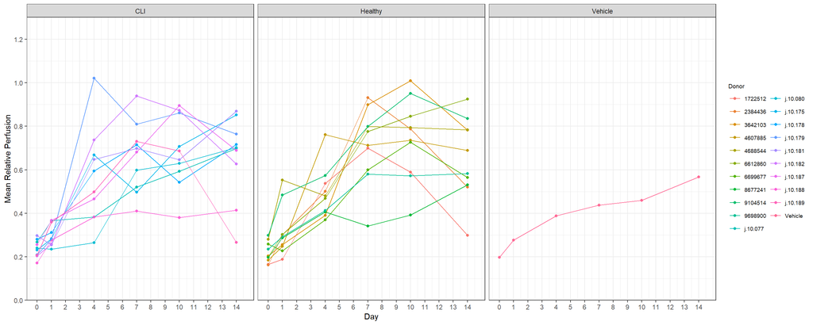